# Complete Guide to DivisiveClusterer

Divisive Variable Clustering (VARCLUS-style)

M2RClust Team

2025-12-02

## Introduction

The `DivisiveClusterer` implements a **divisive (top-down) hierarchical clustering** algorithm for variables, inspired by VARCLUS (SAS). Unlike the `KMeansClusterer` which starts with K clusters and optimizes them, this algorithm:

1. Starts with all variables in a single cluster
2. Iteratively splits the most heterogeneous cluster
3. Stops when the desired number of clusters is reached (or based on a stopping criterion)

### Advantages of Divisive Clustering

- **Deterministic**: No random initialization, 100% reproducible results
- **Interpretable hierarchy**: Complete history of splits
- **Automatic stopping criteria**: Kaiser rule, eigenvalue ratio
- **Hybrid**: Fast path for numeric data, PCAmix for mixed data

### Algorithm Principle

At each iteration:

1. **Selection**: Identify the cluster with the largest 2nd eigenvalue (λ₂)
2. **Verification**: Check stopping criteria (Kaiser, ratio)
3. **Division**: PCA on the cluster, Varimax rotation, assignment based on squared loadings
4. **Update**: Record the split history

## Installation and Loading

```r
library(M2RClust)
```

## Example Data

```r
data(mtcars)

# Larger data to better illustrate the hierarchy
set.seed(123)
n <- 100
p <- 12

# Create data with known cluster structure
data_struct <- data.frame(
  # Group 1: Correlated variables (performance)
  V1 = rnorm(n),
  V2 = NA, V3 = NA,
  # Group 2: Correlated variables (dimensions)
  V4 = rnorm(n),
  V5 = NA, V6 = NA,
  # Group 3: Correlated variables (economy)
  V7 = rnorm(n),
  V8 = NA, V9 = NA,
  # Group 4: Independent variables
  V10 = rnorm(n),
  V11 = rnorm(n),
  V12 = rnorm(n)
)

# Add within-group correlations
data_struct$V2 <- data_struct$V1 * 0.9 + rnorm(n, sd = 0.3)
data_struct$V3 <- data_struct$V1 * 0.85 + rnorm(n, sd = 0.4)
data_struct$V5 <- data_struct$V4 * 0.88 + rnorm(n, sd = 0.35)
data_struct$V6 <- data_struct$V4 * 0.82 + rnorm(n, sd = 0.45)
data_struct$V8 <- data_struct$V7 * 0.87 + rnorm(n, sd = 0.38)
data_struct$V9 <- data_struct$V7 * 0.80 + rnorm(n, sd = 0.5)

cat("Data dimensions:", dim(data_struct), "\n")
```

```
#> Data dimensions: 100 12
```

## Basic Usage

### Creating and Fitting

```r
# Create the divisive clusterer
clusterer <- DivisiveClusterer$new(
  data = data_struct,
  n_clusters = 4,
  standardize = TRUE
)

# Fit
clusterer$fit()
```

```
#> Data mode: NUMERIC (fast correlation path)
#> Divisive clustering completed: 4 clusters formed in 3 iterations
```

```r
# Display
clusterer$print()
```

```
#> === Divisive Clusterer (VARCLUS-style) ===
#>
#> Number of variables: 12
#> Number of clusters: 4
#> Standardization: Yes
#> Fitted: Yes
#>
#> Cluster sizes:
#>
#> 1 2 3 4
#> 4 3 3 2
#>
#> Split history:
#>   Iteration 1: Split cluster 1 (lambda1=3.187, lambda2=2.728, ratio=0.856) -> 2 clusters
#>   Iteration 2: Split cluster 1 (lambda1=3.155, lambda2=2.380, ratio=0.754) -> 3 clusters
#>   Iteration 3: Split cluster 2 (lambda1=2.726, lambda2=1.106, ratio=0.406) -> 4 clusters
#>
#> Global homogeneity: 0.776
```

### Detailed Summary

```r
clusterer$summary()
```

```
#> === Divisive Clusterer Summary ===
#>
#>
#> Cluster 1 (4 variables):
#>   Variables: V1, V2, V3, V11
#>   1st eigenvalue: 2.857
#>   2nd eigenvalue: 0.937
#>   Eigenvalue ratio (lambda2/lambda1): 0.328
#>   Homogeneity: 0.714
#>
#> Cluster 2 (3 variables):
#>   Variables: V4, V5, V6
#>   1st eigenvalue: 2.698
#>   2nd eigenvalue: 0.232
#>   Eigenvalue ratio (lambda2/lambda1): 0.086
#>   Homogeneity: 0.899
#>
#> Cluster 3 (3 variables):
#>   Variables: V7, V8, V9
#>   1st eigenvalue: 2.671
#>   2nd eigenvalue: 0.239
#>   Eigenvalue ratio (lambda2/lambda1): 0.089
#>   Homogeneity: 0.890
#>
#> Cluster 4 (2 variables):
#>   Variables: V10, V12
#>   1st eigenvalue: 1.090
#>   2nd eigenvalue: 0.910
#>   Eigenvalue ratio (lambda2/lambda1): 0.835
#>   Homogeneity: 0.545
```

## Split History

One of the major advantages of `DivisiveClusterer` is access to the complete split history.

### Consulting the History

```r
history <- clusterer$get_split_history()

cat("=== Split History ===\n\n")
```

```
#> === Split History ===
```

```r
for (h in history) {
  cat(sprintf("Iteration %d:\n", h$iteration))
  cat(sprintf("  Split cluster: %d\n", h$split_cluster))
  cat(sprintf("  λ₁ = %.3f, λ₂ = %.3f\n", h$eigenvalue_1, h$eigenvalue_2))
  cat(sprintf("  Ratio λ₂/λ₁ = %.3f\n", h$eigenvalue_ratio))
  cat(sprintf("  Split quality: %.3f\n", h$split_quality))
  cat(sprintf("  Group 1: %s\n", paste(h$variables_group1, collapse = ", ")))
  cat(sprintf("  Group 2: %s\n", paste(h$variables_group2, collapse = ", ")))
  cat("\n")
}
```

```
#> Iteration 1:
#>   Split cluster: 1
#>   λ₁ = 3.187, λ₂ = 2.728
#>   Ratio λ₂/λ₁ = 0.856
#>   Split quality: 0.750
#>   Group 1: V1, V2, V3, V7, V8, V9, V11
#>   Group 2: V4, V5, V6, V10, V12
#>
#> Iteration 2:
#>   Split cluster: 1
#>   λ₁ = 3.155, λ₂ = 2.380
#>   Ratio λ₂/λ₁ = 0.754
#>   Split quality: 0.724
#>   Group 1: V1, V2, V3, V11
#>   Group 2: V7, V8, V9
#>
#> Iteration 3:
#>   Split cluster: 2
#>   λ₁ = 2.726, λ₂ = 1.106
#>   Ratio λ₂/λ₁ = 0.406
#>   Split quality: 0.745
#>   Group 1: V4, V5, V6
#>   Group 2: V10, V12
```

### Summary Table

```r
details <- clusterer$get_split_details()
print(details)
```

```
#>   iteration split_cluster eigenvalue_1 eigenvalue_2 eigenvalue_ratio
#> 1         1             1     3.186609     2.727841        0.8560324
#> 2         2             1     3.155130     2.379823        0.7542710
#> 3         3             2     2.725832     1.105514        0.4055694
#>   n_clusters_after n_vars_group1 n_vars_group2 split_quality
#> 1                2             7             5     0.7503140
#> 2                3             4             3     0.7243182
#> 3                4             3             2     0.7445645
```

## Dendrogram Visualization

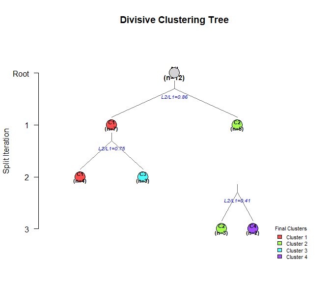

Split tree (top-down dendrogram)

```r
clusterer$plot_split_dendrogram(
  main = "Divisive Clustering Tree",
  show_eigenvalues = TRUE,
  show_vars = TRUE
)
```

## Stopping Criteria

### Kaiser Criterion

The Kaiser criterion stops splitting when λ₂ < 1 (no significant secondary component).

```r
clusterer_kaiser <- DivisiveClusterer$new(
  data = data_struct,
  n_clusters = 10,  # Theoretical maximum
  stop_at_kaiser = TRUE
)
clusterer_kaiser$fit()
```

```
#> Data mode: NUMERIC (fast correlation path)
#> Kaiser criterion: Stopping at 4 clusters (max lambda2 = 0.937 < 1.0)
#> Divisive clustering completed: 4 clusters formed in 4 iterations
```

```r
cat("Clusters formed with Kaiser:", max(clusterer_kaiser$clusters), "\n")
```

```
#> Clusters formed with Kaiser: 4
```

```r
clusterer_kaiser$print()
```

```
#> === Divisive Clusterer (VARCLUS-style) ===
#>
#> Number of variables: 12
#> Number of clusters: 10
#> Standardization: Yes
#> Fitted: Yes
#>
#> Cluster sizes:
#>
#> 1 2 3 4
#> 4 3 3 2
#>
#> Split history:
#>   Iteration 1: Split cluster 1 (lambda1=3.187, lambda2=2.728, ratio=0.856) -> 2 clusters
#>   Iteration 2: Split cluster 1 (lambda1=3.155, lambda2=2.380, ratio=0.754) -> 3 clusters
#>   Iteration 3: Split cluster 2 (lambda1=2.726, lambda2=1.106, ratio=0.406) -> 4 clusters
#>
#> Global homogeneity: 0.776
```

### Eigenvalue Ratio

Stops when λ₂/λ₁ falls below a threshold (cluster already homogeneous).

```r
clusterer_ratio <- DivisiveClusterer$new(
  data = data_struct,
  n_clusters = 10,
  min_eigenvalue_ratio = 0.2  # Stop if λ₂/λ₁ < 0.2
)
clusterer_ratio$fit()
```

```
#> Data mode: NUMERIC (fast correlation path)
#> Eigenvalue ratio criterion: Stopping at 5 clusters (lambda2/lambda1 = 0.089 < 0.200)
#> Divisive clustering completed: 5 clusters formed in 5 iterations
```

```r
cat("Clusters formed with ratio 0.2:", max(clusterer_ratio$clusters), "\n")
```

```
#> Clusters formed with ratio 0.2: 5
```

### Minimum Cluster Size

Prevents splitting clusters that are too small.

```r
clusterer_minsize <- DivisiveClusterer$new(
  data = data_struct,
  n_clusters = 6,
  min_cluster_size = 3  # At least 3 variables to split
)
clusterer_minsize$fit()
```

```
#> Data mode: NUMERIC (fast correlation path)
#> Eigenvalue ratio criterion: Stopping at 5 clusters (lambda2/lambda1 = 0.089 < 0.100)
#> Divisive clustering completed: 5 clusters formed in 5 iterations
```

```r
clusterer_minsize$print()
```

```
#> === Divisive Clusterer (VARCLUS-style) ===
#>
#> Number of variables: 12
#> Number of clusters: 6
#> Standardization: Yes
#> Fitted: Yes
#>
#> Cluster sizes:
#>
#> 1 2 3 4 5
#> 3 3 3 2 1
#>
#> Split history:
#>   Iteration 1: Split cluster 1 (lambda1=3.187, lambda2=2.728, ratio=0.856) -> 2 clusters
#>   Iteration 2: Split cluster 1 (lambda1=3.155, lambda2=2.380, ratio=0.754) -> 3 clusters
#>   Iteration 3: Split cluster 2 (lambda1=2.726, lambda2=1.106, ratio=0.406) -> 4 clusters
#>   Iteration 4: Split cluster 1 (lambda1=2.857, lambda2=0.937, ratio=0.328) -> 5 clusters
#>
#> Global homogeneity: 0.854
```

## Rotation Methods

### Varimax (default)

Orthogonal rotation that maximizes the variance of squared loadings.

```r
clust_varimax <- DivisiveClusterer$new(
  data = data_struct,
  n_clusters = 4,
  rotation_method = "varimax"
)
clust_varimax$fit()
```

```
#> Data mode: NUMERIC (fast correlation path)
#> Divisive clustering completed: 4 clusters formed in 3 iterations
```

```r
cat("Homogeneity (Varimax):", round(clust_varimax$get_homogeneity(), 4), "\n")
```

```
#> Homogeneity (Varimax): 0.7763
```

### Promax

Oblique rotation, allows correlated factors.

```r
clust_promax <- DivisiveClusterer$new(
  data = data_struct,
  n_clusters = 4,
  rotation_method = "promax",
  promax_m = 4  # Power parameter
)
clust_promax$fit()
```

```
#> Data mode: NUMERIC (fast correlation path)
#> Divisive clustering completed: 4 clusters formed in 3 iterations
```

```r
cat("Homogeneity (Promax):", round(clust_promax$get_homogeneity(), 4), "\n")
```

```
#> Homogeneity (Promax): 0.7763
```

### No Rotation

```r
clust_none <- DivisiveClusterer$new(
  data = data_struct,
  n_clusters = 4,
  rotation_method = "none"
)
clust_none$fit()
```

```
#> Data mode: NUMERIC (fast correlation path)
#> Divisive clustering completed: 4 clusters formed in 3 iterations
```

```r
cat("Homogeneity (No rotation):", round(clust_none$get_homogeneity(), 4), "\n")
```

```
#> Homogeneity (No rotation): 0.7829
```

## Cluster Selection Criterion

### By λ₂ (default)

Splits the cluster with the largest 2nd eigenvalue.

```r
clust_ev2 <- DivisiveClusterer$new(
  data = data_struct,
  n_clusters = 4,
  split_criterion = "eigenvalue2"
)
clust_ev2$fit()
```

```
#> Data mode: NUMERIC (fast correlation path)
#> Divisive clustering completed: 4 clusters formed in 3 iterations
```

### By Homogeneity

Splits the least homogeneous cluster (1 - λ₁/(λ₁+λ₂)).

```r
clust_homog <- DivisiveClusterer$new(
  data = data_struct,
  n_clusters = 4,
  split_criterion = "homogeneity"
)
clust_homog$fit()
```

```
#> Data mode: NUMERIC (fast correlation path)
#> Divisive clustering completed: 4 clusters formed in 3 iterations
```

## Visualizations

The `DivisiveClusterer` has specific visualizations that are well-suited to its hierarchical nature:

### Best Visualizations for Divisive Clustering

| Visualization | Relevance | Why |
| --- | --- | --- |
| **Dendrogram** | ⭐⭐⭐ | Shows the split history - signature plot |
| **Correlation Heatmap** | ⭐⭐⭐ | Reveals block structure by cluster |
| **Cluster Quality** | ⭐⭐ | Homogeneity is the optimization criterion |
| **Network Graph** | ⭐⭐ | Visualizes variable relationships |
| Correlation Circle | ⭐ | Global PCA doesn’t reflect split logic |

### Correlation Heatmap (Recommended)

The heatmap reordered by cluster clearly shows the block-diagonal structure that the algorithm discovers:

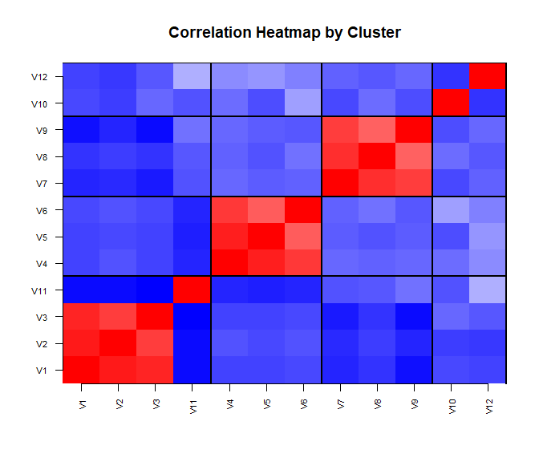

Correlation heatmap showing cluster structure

```r
plot_correlation_heatmap(clusterer, reorder = TRUE)
```

### Cluster Quality Metrics

Shows cluster sizes and homogeneity (λ₁ / Σλ) - the criterion optimized at each split:

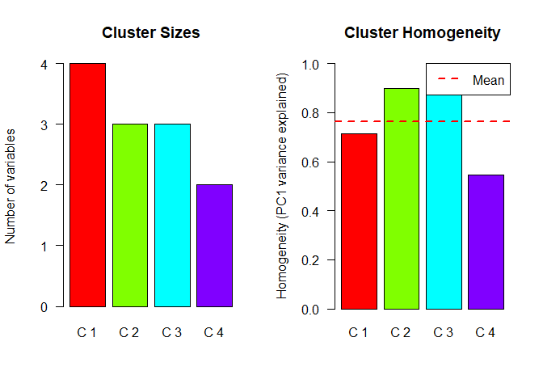

Cluster sizes and homogeneity

```r
plot_cluster_quality(clusterer)
```

### Network Graph (if igraph available)

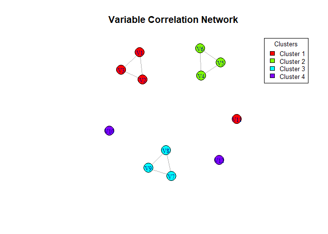

Variable correlation network

```r
plot_network_graph(clusterer, threshold = 0.5)
```

### Note on Correlation Circle

The correlation circle (`plot_clustering_2d()`) uses a global PCA which doesn’t naturally reflect the successive splits of the divisive algorithm. It can still be used for comparison with KMeansClusterer, but the dendrogram is more informative for understanding the hierarchical structure.

## Prediction on New Variables

```r
# New variables
new_vars <- data.frame(
  NewV1 = data_struct$V1 * 0.7 + rnorm(n, sd = 0.5),  # Close to group 1
  NewV2 = data_struct$V4 * 0.6 + rnorm(n, sd = 0.6),  # Close to group 2
  NewV3 = rnorm(n)  # Independent
)

predictions <- clusterer$predict(new_vars)
print(predictions)
```

```
#> NewV1 NewV2 NewV3
#>     1     2     2
```

## Selecting the Number of Clusters

The `DivisiveClusterer` is compatible with K selection methods.

### Elbow Method

```
#> Calculating elbow method...
#>   K = 2...
#> Data mode: NUMERIC (fast correlation path)
#> Divisive clustering completed: 2 clusters formed in 1 iterations
#>   K = 3...
#> Data mode: NUMERIC (fast correlation path)
#> Divisive clustering completed: 3 clusters formed in 2 iterations
#>   K = 4...
#> Data mode: NUMERIC (fast correlation path)
#> Divisive clustering completed: 4 clusters formed in 3 iterations
#>   K = 5...
#> Data mode: NUMERIC (fast correlation path)
#> Divisive clustering completed: 5 clusters formed in 4 iterations
#>   K = 6...
#> Data mode: NUMERIC (fast correlation path)
#> Eigenvalue ratio criterion: Stopping at 5 clusters (lambda2/lambda1 = 0.089 < 0.100)
#> Divisive clustering completed: 5 clusters formed in 5 iterations
#>   K = 7...
#> Data mode: NUMERIC (fast correlation path)
#> Eigenvalue ratio criterion: Stopping at 5 clusters (lambda2/lambda1 = 0.089 < 0.100)
#> Divisive clustering completed: 5 clusters formed in 5 iterations
#>   K = 8...
#> Data mode: NUMERIC (fast correlation path)
#> Eigenvalue ratio criterion: Stopping at 5 clusters (lambda2/lambda1 = 0.089 < 0.100)
#> Divisive clustering completed: 5 clusters formed in 5 iterations
```

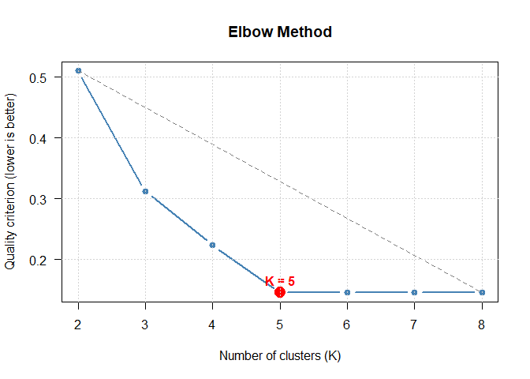

Elbow method - DivisiveClusterer

```
#>
#> K suggested by elbow method: 5
cat("Suggested K:", elbow_res$suggested_k, "\n")
#> Suggested K: 5
```

```r
elbow_res <- elbow_method(
  DivisiveClusterer,
  data_struct,
  k_range = 2:8,
  plot = TRUE
)
```

### Complete Comparison

```
#> ========================================
#> COMPARISON OF K SELECTION METHODS
#> ========================================
#>
#>
#> 1. ELBOW METHOD
#> -------------------
#> Calculating elbow method...
#>   K = 2...
#> Data mode: NUMERIC (fast correlation path)
#> Divisive clustering completed: 2 clusters formed in 1 iterations
#>   K = 3...
#> Data mode: NUMERIC (fast correlation path)
#> Divisive clustering completed: 3 clusters formed in 2 iterations
#>   K = 4...
#> Data mode: NUMERIC (fast correlation path)
#> Divisive clustering completed: 4 clusters formed in 3 iterations
#>   K = 5...
#> Data mode: NUMERIC (fast correlation path)
#> Divisive clustering completed: 5 clusters formed in 4 iterations
#>   K = 6...
#> Data mode: NUMERIC (fast correlation path)
#> Eigenvalue ratio criterion: Stopping at 5 clusters (lambda2/lambda1 = 0.089 < 0.100)
#> Divisive clustering completed: 5 clusters formed in 5 iterations
#>   K = 7...
#> Data mode: NUMERIC (fast correlation path)
#> Eigenvalue ratio criterion: Stopping at 5 clusters (lambda2/lambda1 = 0.089 < 0.100)
#> Divisive clustering completed: 5 clusters formed in 5 iterations
#>
#> K suggested by elbow method: 5
#>
#> 2. SILHOUETTE METHOD
#> ---------------------------
#> Calculating silhouette method...
#>   K = 2...
#> Data mode: NUMERIC (fast correlation path)
#> Divisive clustering completed: 2 clusters formed in 1 iterations
#>   K = 3...
#> Data mode: NUMERIC (fast correlation path)
#> Divisive clustering completed: 3 clusters formed in 2 iterations
```

[output cut: 26 more lines]

```
#> Divisive clustering completed: 3 clusters formed in 2 iterations
#>   K = 4...
#> Data mode: NUMERIC (fast correlation path)
#> Divisive clustering completed: 4 clusters formed in 3 iterations
#>   K = 5...
#> Data mode: NUMERIC (fast correlation path)
#> Divisive clustering completed: 5 clusters formed in 4 iterations
#>   K = 6...
#> Data mode: NUMERIC (fast correlation path)
#> Eigenvalue ratio criterion: Stopping at 5 clusters (lambda2/lambda1 = 0.089 < 0.100)
#> Divisive clustering completed: 5 clusters formed in 5 iterations
#>   K = 7...
#> Data mode: NUMERIC (fast correlation path)
#> Eigenvalue ratio criterion: Stopping at 5 clusters (lambda2/lambda1 = 0.089 < 0.100)
#> Divisive clustering completed: 5 clusters formed in 5 iterations
```

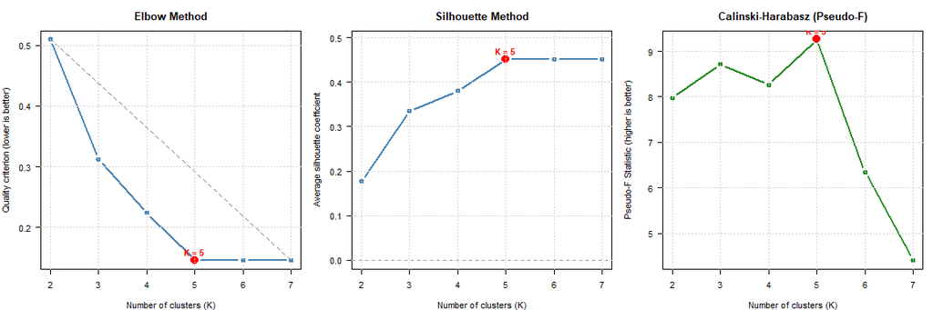

```
#>
#> K suggested by Calinski-Harabasz: 5
#> Pseudo-F score: 9.258
#>
#> ========================================
#> SUMMARY OF RECOMMENDATIONS
#> ========================================
#> Elbow Method:           K = 5
#> Silhouette Method:      K = 5
#> Calinski-Harabasz:      K = 5
#>
#> Consensus (majority vote): K = 5
#> ========================================
cat("Consensus K:", comparison$consensus_k, "\n")
#> Consensus K: 5
```

```r
comparison <- compare_k_selection_methods(
  DivisiveClusterer,
  data_struct,
  k_range = 2:7,
  plot = TRUE
)
```

## Mixed Data

The `DivisiveClusterer` automatically detects the data type and uses: - **Fast path**: `eigen(cor(X))` for purely numeric data - **PCAmix**: For mixed data (numeric + categorical)

```r
# Mixed data
data_mixed <- data_struct[, 1:6]
data_mixed$Cat1 <- factor(sample(c("A", "B", "C"), n, replace = TRUE))
data_mixed$Cat2 <- factor(sample(c("X", "Y"), n, replace = TRUE))

str(data_mixed)
```

```
#> 'data.frame':    100 obs. of  8 variables:
#>  $ V1  : num  -0.5605 -0.2302 1.5587 0.0705 0.1293 ...
#>  $ V2  : num  -0.182 -0.215 1.393 -0.391 0.353 ...
#>  $ V3  : num  -0.768 -0.812 1.048 0.107 -0.436 ...
#>  $ V4  : num  -0.71 0.257 -0.247 -0.348 -0.952 ...
#>  $ V5  : num  -0.50046 -0.00425 0.08223 0.09769 -0.74073 ...
#>  $ V6  : num  -1.0389 -0.1454 -0.0675 0.4526 -0.2922 ...
#>  $ Cat1: Factor w/ 3 levels "A","B","C": 3 3 2 1 1 3 2 3 2 1 ...
#>  $ Cat2: Factor w/ 2 levels "X","Y": 2 2 1 1 1 1 1 2 1 1 ...
```

```r
if (requireNamespace("PCAmixdata", quietly = TRUE)) {
  clusterer_mixed <- DivisiveClusterer$new(
    data = data_mixed,
    n_clusters = 3
  )
  clusterer_mixed$fit()
  clusterer_mixed$print()
}
```

```
#> Data mode: MIXED (PCAmix path for categorical variables)
#> Divisive clustering completed: 3 clusters formed in 2 iterations
#> === Divisive Clusterer (VARCLUS-style) ===
#>
#> Number of variables: 8
#> Number of clusters: 3
#> Standardization: Yes
#> Fitted: Yes
#>
#> Cluster sizes:
#>
#> 1 2 3
#> 4 3 1
#>
#> Split history:
#>   Iteration 1: Split cluster 1 (lambda1=2.953, lambda2=2.649, ratio=0.897) -> 2 clusters
#>   Iteration 2: Split cluster 2 (lambda1=2.724, lambda2=1.000, ratio=0.367) -> 3 clusters
#>
#> Global homogeneity: 0.815
```

## Comparison with KMeansClusterer

```r
# Same data, same parameters (use numeric columns only)
data(mtcars)
data_test <- mtcars[, c("mpg", "cyl", "disp", "hp", "wt", "qsec")]

# DivisiveClusterer
div_clust <- DivisiveClusterer$new(data = data_test, n_clusters = 3)
div_clust$fit()
```

```
#> Data mode: NUMERIC (fast correlation path)
#> Eigenvalue ratio criterion: Stopping at 2 clusters (lambda2/lambda1 = 0.062 < 0.100)
#> Divisive clustering completed: 2 clusters formed in 2 iterations
```

```r
# KMeansClusterer
km_clust <- KMeansClusterer$new(data = data_test, n_clusters = 3, seed = 42)
km_clust$fit()

cat("=== Comparison ===\n")
```

```
#> === Comparison ===
```

```r
cat(sprintf("DivisiveClusterer - Homogeneity: %.4f\n", div_clust$get_homogeneity()))
```

```
#> DivisiveClusterer - Homogeneity: 0.8798
```

```r
cat(sprintf("KMeansClusterer   - Homogeneity: %.4f\n", km_clust$get_homogeneity()))
```

```
#> KMeansClusterer   - Homogeneity: 0.9284
```

```r
# Compare assignments
cat("\nDivisiveClusterer assignments:\n")
```

```
#>
#> DivisiveClusterer assignments:
```

```r
print(table(div_clust$clusters))
```

```
#>
#> 1 2
#> 4 2
```

```r
cat("\nKMeansClusterer assignments:\n")
```

```
#>
#> KMeansClusterer assignments:
```

```r
print(table(km_clust$clusters))
```

```
#>
#> 1 2 3
#> 4 1 1
```

### Side-by-Side Visualization

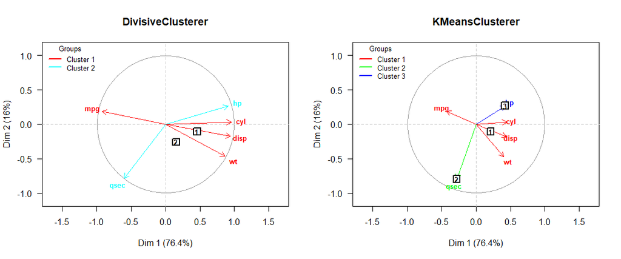

```r
par(mfrow = c(1, 2))
plot_clustering_2d(div_clust, main = "DivisiveClusterer")
plot_clustering_2d(km_clust, main = "KMeansClusterer")
```

```r
par(mfrow = c(1, 1))
```

## Recommended Use Cases

### When to Use DivisiveClusterer?

1. **Absolute reproducibility**: 100% deterministic results
2. **Hierarchical interpretation**: Understanding how groups form
3. **Automatic stopping**: Let the algorithm determine optimal K
4. **Large datasets**: The fast path is very efficient

### When to Prefer KMeansClusterer?

1. **Fixed and known K**: Direct optimization for K clusters
2. **Initialization flexibility**: Testing multiple starts
3. **Highly heterogeneous data**: Better convergence to global optimum

## Export and Integration

### Retrieving Assignments

```r
assignments <- clusterer$get_cluster_assignments()
head(assignments)
```

```
#>   variable cluster homogeneity
#> 1       V1       1    0.714160
#> 2       V2       1    0.714160
#> 3       V3       1    0.714160
#> 4       V4       2    0.899325
#> 5       V5       2    0.899325
#> 6       V6       2    0.899325
```

### Retrieving the Hierarchical Structure

```r
tree <- clusterer$get_hierarchy_tree()
str(tree, max.level = 2)
```

```
#> List of 4
#>  $ n_clusters    : num 4
#>  $ n_iterations  : int 3
#>  $ splits        :List of 3
#>   ..$ :List of 9
#>   ..$ :List of 9
#>   ..$ :List of 9
#>  $ final_clusters:List of 4
#>   ..$ 1: int 4
#>   ..$ 2: int 3
#>   ..$ 3: int 3
#>   ..$ 4: int 2
```

### Cluster Centers

```r
centers <- clusterer$get_centers()
cat("Number of centers:", length(centers), "\n")
```

```
#> Number of centers: 4
```

```r
cat("Length of first center:", length(centers[[1]]), "observations\n")
```

```
#> Length of first center: 100 observations
```

## Advanced Parameters - Summary

| Parameter | Default | Description |
| --- | --- | --- |
| `n_clusters` | - | Maximum number of clusters |
| `standardize` | `TRUE` | Standardize the data |
| `min_cluster_size` | `3` | Minimum size to split |
| `rotation_method` | `"varimax"` | `"varimax"`, `"promax"`, `"none"` |
| `split_criterion` | `"eigenvalue2"` | `"eigenvalue2"` or `"homogeneity"` |
| `stop_at_kaiser` | `FALSE` | Stop if λ₂ < 1 |
| `min_eigenvalue_ratio` | `0.1` | Minimum λ₂/λ₁ ratio |
| `promax_m` | `4` | Power for Promax |

## Conclusion

The `DivisiveClusterer` offers a complementary approach to the `KMeansClusterer`:

- **Determinism**: Ideal for reproducibility and reports
- **Interpretability**: The split history tells a story
- **Flexibility**: Multiple stopping criteria for context adaptation
- **Performance**: Hybrid path optimized by data type

To explore your data, start with `DivisiveClusterer` with `stop_at_kaiser = TRUE` to discover the natural structure, then refine with `KMeansClusterer` if needed.

## References

- Sarle, W. S. (1990). The VARCLUS Procedure. *SAS/STAT User’s Guide*, Version 6, Fourth Edition.
- Chavent, M., et al. (2012). ClustOfVar: An R Package for the Clustering of Variables.